# Introduction to machine learning

Authors

Affiliations

dr.sc. Paula Štancl

Kuzman Consulting d.o.o

dr.sc. Andrea Gelemanović

MedILS, UNIST

# Load libraries

```r
# Data manipulation
library(data.table)

# Visualization
library(ggplot2)
library(ggpubr)
library(corrplot)

# Machine learning
library(caret)
library(MASS)
library(factoextra)
library(Boruta)
```

**`set.seed()`** in R sets the random number generator seed, which ensures that any random operations (like splitting data into training/test sets, random sampling, cross-validation folds) are reproducible.

When you perform these tasks they involve randomness. Without set.seed(), the results would change every time you run the code. By setting a seed, you ensure that the same random split happens every time, and that others can reproduce your results exactly.

```r
# Set seed for reproducibility
set.seed(12345)
```

# Import dataset

We will once again work with [HeartDisease](https://vincentarelbundock.github.io/Rdatasets/csv/CardioDataSets/heartdisease_tbl_df.csv) dataset.

```r
heart_disease <- fread("https://vincentarelbundock.github.io/Rdatasets/csv/CardioDataSets/heartdisease_tbl_df.csv")
class(heart_disease)
```

```
[1] "data.table" "data.frame"
```

# Research question

Let’s define our research question to be this: “What predicts heart disease?”

# Data preprocessing

Remember how your data looks like:

```r
str(heart_disease)
```

```
Classes 'data.table' and 'data.frame':  303 obs. of  10 variables:
 $ rownames             : int  1 2 3 4 5 6 7 8 9 10 ...
 $ Age                  : int  63 67 67 37 41 56 62 57 63 53 ...
 $ Sex                  : chr  "Male" "Male" "Male" "Male" ...
 $ ChestPain            : chr  "Typical angina" "Asymptomatic" "Asymptomatic" "Non-anginal pain" ...
 $ BP                   : int  145 160 120 130 130 120 140 120 130 140 ...
 $ Cholesterol          : int  233 286 229 250 204 236 268 354 254 203 ...
 $ BloodSugar           : logi  TRUE FALSE FALSE FALSE FALSE FALSE ...
 $ MaximumHR            : int  150 108 129 187 172 178 160 163 147 155 ...
 $ ExerciseInducedAngina: chr  "No" "Yes" "Yes" "No" ...
 $ HeartDisease         : chr  "No" "Yes" "Yes" "No" ...
 - attr(*, ".internal.selfref")=<externalptr>
```

```r
head(heart_disease)
```

| rownames | Age | Sex | ChestPain | BP | Cholesterol | BloodSugar | MaximumHR | ExerciseInducedAngina | HeartDisease |
| --- | --- | --- | --- | --- | --- | --- | --- | --- | --- |
| 1 | 63 | Male | Typical angina | 145 | 233 | TRUE | 150 | No | No |
| 2 | 67 | Male | Asymptomatic | 160 | 286 | FALSE | 108 | Yes | Yes |
| 3 | 67 | Male | Asymptomatic | 120 | 229 | FALSE | 129 | Yes | Yes |
| 4 | 37 | Male | Non-anginal pain | 130 | 250 | FALSE | 187 | No | No |
| 5 | 41 | Female | Atypical angina | 130 | 204 | FALSE | 172 | No | No |
| 6 | 56 | Male | Atypical angina | 120 | 236 | FALSE | 178 | No | No |

```r
summary(heart_disease)
```

```
    rownames          Age            Sex             ChestPain
 Min.   :  1.0   Min.   :29.00   Length:303         Length:303
 1st Qu.: 76.5   1st Qu.:48.00   Class :character   Class :character
 Median :152.0   Median :56.00   Mode  :character   Mode  :character
 Mean   :152.0   Mean   :54.44
 3rd Qu.:227.5   3rd Qu.:61.00
 Max.   :303.0   Max.   :77.00
       BP         Cholesterol    BloodSugar        MaximumHR
 Min.   : 94.0   Min.   :126.0   Mode :logical   Min.   : 71.0
 1st Qu.:120.0   1st Qu.:211.0   FALSE:258       1st Qu.:133.5
 Median :130.0   Median :241.0   TRUE :45        Median :153.0
 Mean   :131.7   Mean   :246.7                   Mean   :149.6
 3rd Qu.:140.0   3rd Qu.:275.0                   3rd Qu.:166.0
 Max.   :200.0   Max.   :564.0                   Max.   :202.0
 ExerciseInducedAngina HeartDisease
 Length:303            Length:303
 Class :character      Class :character
 Mode  :character      Mode  :character
```

```r
table(heart_disease$HeartDisease)
```

```
 No Yes
164 139
```

## Convert categorical variables to factor

```r
heart_disease[, Sex := as.factor(Sex)]
heart_disease[, ChestPain := as.factor(ChestPain)]
heart_disease[, BloodSugar := as.factor(BloodSugar)]
heart_disease[, ExerciseInducedAngina := as.factor(ExerciseInducedAngina)]
heart_disease[, HeartDisease := as.factor(HeartDisease)]

str(heart_disease)
```

```
Classes 'data.table' and 'data.frame':  303 obs. of  10 variables:
 $ rownames             : int  1 2 3 4 5 6 7 8 9 10 ...
 $ Age                  : int  63 67 67 37 41 56 62 57 63 53 ...
 $ Sex                  : Factor w/ 2 levels "Female","Male": 2 2 2 2 1 2 1 1 2 2 ...
 $ ChestPain            : Factor w/ 4 levels "Asymptomatic",..: 4 1 1 3 2 2 1 1 1 1 ...
 $ BP                   : int  145 160 120 130 130 120 140 120 130 140 ...
 $ Cholesterol          : int  233 286 229 250 204 236 268 354 254 203 ...
 $ BloodSugar           : Factor w/ 2 levels "FALSE","TRUE": 2 1 1 1 1 1 1 1 1 2 ...
 $ MaximumHR            : int  150 108 129 187 172 178 160 163 147 155 ...
 $ ExerciseInducedAngina: Factor w/ 2 levels "No","Yes": 1 2 2 1 1 1 1 2 1 2 ...
 $ HeartDisease         : Factor w/ 2 levels "No","Yes": 1 2 2 1 1 1 2 1 2 2 ...
 - attr(*, ".internal.selfref")=<externalptr>
```

## Evaluate correlation patterns

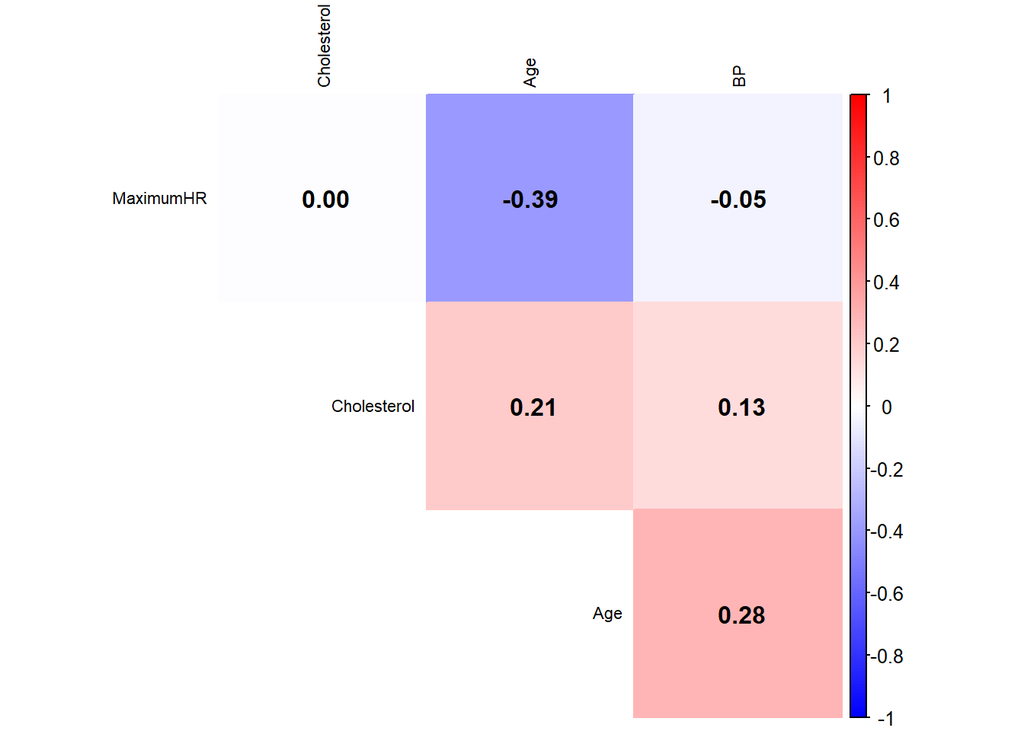

```r
# Calculate Pearson's correlation coefficient
cor_matrix <- cor(heart_disease[, .SD, .SDcols = is.numeric][, -1],
                  method = "pearson",
                  use = "complete.obs")

# Plot corrplot to evaluate correlation patterns among the data
corrplot(cor_matrix,
         method = "color",
         type = "upper",
         diag = FALSE,
         order = "hclust",
         tl.cex = 0.7,
         tl.col = "black", addCoef.col = "black",
         col = colorRampPalette(c("blue", "white", "red"))(200))
```

## Data scaling

Before fitting any machine learning model, scaling of the dataset needs to be performed. Usually, all algorithms are sensitive to variables that have incomparable units, leading to misleading results.

To avoid this problem (because all variables should be treated equally), the variables need to be transformed to be on a similar scale which allows them to be compared correctly using the distance metric.

The most popular method for that is standardization, which consists in subtracting the average value from the feature value and then dividing it by its standard deviation. This technique will allow obtaining features with a mean of 0 and a deviation of 1.

In R, standardization can be done with the `scale()` function.

```r
# Summary of the data
summary(heart_disease)
```

```
    rownames          Age            Sex                 ChestPain
 Min.   :  1.0   Min.   :29.00   Female: 97   Asymptomatic    :144
 1st Qu.: 76.5   1st Qu.:48.00   Male  :206   Atypical angina : 50
 Median :152.0   Median :56.00                Non-anginal pain: 86
 Mean   :152.0   Mean   :54.44                Typical angina  : 23
 3rd Qu.:227.5   3rd Qu.:61.00
 Max.   :303.0   Max.   :77.00
       BP         Cholesterol    BloodSugar    MaximumHR
 Min.   : 94.0   Min.   :126.0   FALSE:258   Min.   : 71.0
 1st Qu.:120.0   1st Qu.:211.0   TRUE : 45   1st Qu.:133.5
 Median :130.0   Median :241.0               Median :153.0
 Mean   :131.7   Mean   :246.7               Mean   :149.6
 3rd Qu.:140.0   3rd Qu.:275.0               3rd Qu.:166.0
 Max.   :200.0   Max.   :564.0               Max.   :202.0
 ExerciseInducedAngina HeartDisease
 No :204               No :164
 Yes: 99               Yes:139
```

```r
# Data scaling
heart_disease_scaled <- scale(heart_disease[, .SD, .SDcols = is.numeric][, -1])

# Summary of the normalized data
summary(heart_disease_scaled)
```

```
      Age                BP            Cholesterol        MaximumHR
 Min.   :-2.8145   Min.   :-2.14149   Min.   :-2.3310   Min.   :-3.4364
 1st Qu.:-0.7124   1st Qu.:-0.66420   1st Qu.:-0.6894   1st Qu.:-0.7041
 Median : 0.1727   Median :-0.09601   Median :-0.1100   Median : 0.1483
 Mean   : 0.0000   Mean   : 0.00000   Mean   : 0.0000   Mean   : 0.0000
 3rd Qu.: 0.7259   3rd Qu.: 0.47218   3rd Qu.: 0.5467   3rd Qu.: 0.7166
 Max.   : 2.4961   Max.   : 3.88132   Max.   : 6.1283   Max.   : 2.2904
```

# Part 1: Unsupervised learning

Main categories of unsupervised learning are:

- Clustering which aims to find structure and patterns in the unlabeled data
- Dimensionality reduction which aims to decrease the number of features to describe an observation while preserving its essential structure and characteristics

## PCA analysis

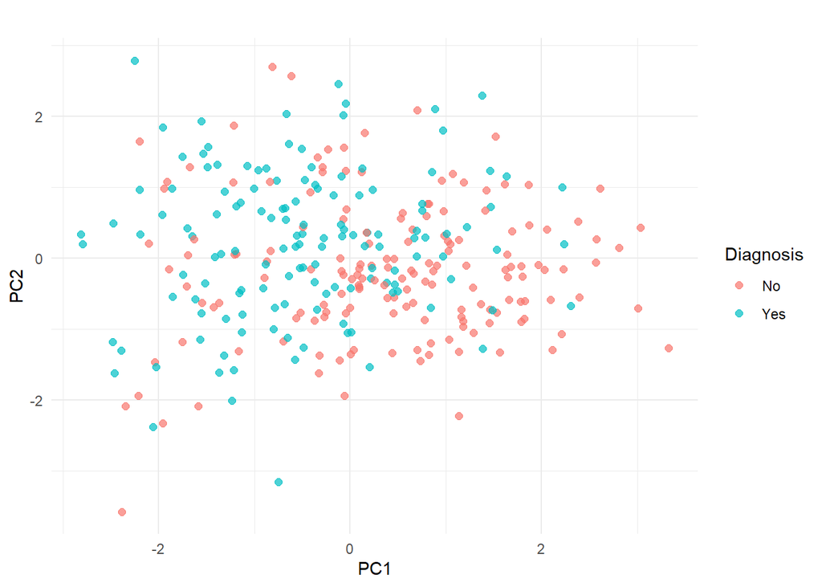

```r
# Run PCA
pca_result <- prcomp(heart_disease_scaled, scale. = FALSE)

# Combine PCA and original label
pca_df <- data.frame(pca_result$x,
                     diagnosis = heart_disease$HeartDisease)

# Plot PC1 vs PC2 and color by diagnosis
ggplot(pca_df, aes(PC1, PC2, col = diagnosis)) +
  geom_point(size = 2, alpha = 0.7) +
  theme_minimal() +
  labs(title = "", color = "Diagnosis")
```

```r
# Explained variance
summary(pca_result)
```

```
Importance of components:
                          PC1    PC2    PC3    PC4
Standard deviation     1.2580 1.0208 0.9294 0.7154
Proportion of Variance 0.3956 0.2605 0.2159 0.1280
Cumulative Proportion  0.3956 0.6561 0.8720 1.0000
```

## K-means clustering

```r
km.out_initial <- kmeans(heart_disease_scaled,
                         centers = 2,
                         nstart = 20)
km.out_initial
```

```
K-means clustering with 2 clusters of sizes 154, 149

Cluster means:
         Age         BP Cholesterol  MaximumHR
1  0.6993066  0.3913779   0.2368136 -0.5619240
2 -0.7227733 -0.4045114  -0.2447603  0.5807805

Clustering vector:
  [1] 1 1 1 2 2 2 1 1 1 2 1 1 1 2 1 2 2 2 2 2 1 1 2 2 1 2 2 1 2 2 1 2 1 1 2 2 2
 [38] 1 1 1 1 2 1 1 1 2 2 1 1 2 2 1 2 2 1 1 2 2 2 1 1 2 1 2 1 1 1 2 1 2 1 1 1 1
 [75] 2 1 1 1 2 1 2 1 2 1 2 2 2 1 2 2 1 1 1 2 1 2 1 1 2 2 2 2 1 1 2 2 2 1 1 2 1
[112] 1 2 2 1 2 2 2 1 1 2 1 2 1 1 2 1 1 2 2 2 2 2 2 2 2 1 1 2 2 1 1 2 1 2 2 1 2
[149] 2 2 2 2 1 1 1 1 2 2 1 1 2 1 2 1 2 2 2 2 2 2 1 1 1 1 1 1 2 1 2 2 2 1 2 1 1
[186] 2 2 1 1 1 2 1 2 1 1 1 1 2 2 1 2 1 2 1 2 2 1 1 2 1 2 2 2 1 2 2 2 2 1 2 2 2
[223] 2 1 2 2 2 1 1 1 2 1 2 1 1 1 1 2 2 2 2 2 2 1 1 1 2 2 2 1 1 1 1 2 2 2 1 1 1
[260] 1 2 1 1 2 1 1 2 1 2 2 1 1 1 1 2 1 1 2 1 1 1 2 1 2 1 1 1 1 2 2 1 1 2 1 1 2
[297] 1 1 2 1 1 2 2

Within cluster sum of squares by cluster:
[1] 554.5513 335.8822
 (between_SS / total_SS =  26.3 %)

Available components:

[1] "cluster"      "centers"      "totss"        "withinss"     "tot.withinss"
[6] "betweenss"    "size"         "iter"         "ifault"
```

```r
# Evaluate size of each cluster
km.out_initial$size
```

```
[1] 154 149
```

**Important**

*How to select for optimal number of clusters?*

When you run k-means clustering with different values of k (e.g., from 1 to 10), the algorithm calculates a value called **Total Within-Cluster Sum of Squares (WSS)** - it measures how compact the clusters are (i.e. how close data points are to their assigned cluster centers).

As k increases, WSS decreases because more clusters mean smaller, tighter groups. But adding more clusters always reduces WSS and at some point, the benefit becomes marginal.

For visual representation of this we can run Elbow plot and find a point where the rate of decrease sharply changes - that elbow suggests an optimal balance.

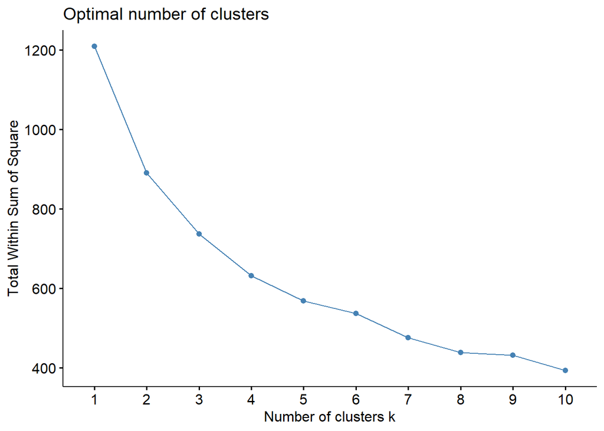

```r
# Elbow method
fviz_nbclust(heart_disease_scaled,
             kmeans,
             method = "wss")
```

Let’s visualize our K-means clusters:

```r
# Combine K-means and original label
kmeans_df <- cbind(heart_disease,
                   cluster = as.factor(km.out_initial$cluster)
                   )

# How well did k-means clustering do in comparison with known groups?
table(kmeans_df$cluster, kmeans_df$HeartDisease)
```

```
     No Yes
  1  56  98
  2 108  41
```

Let’s merge now our K-means clustering with PCA visualization

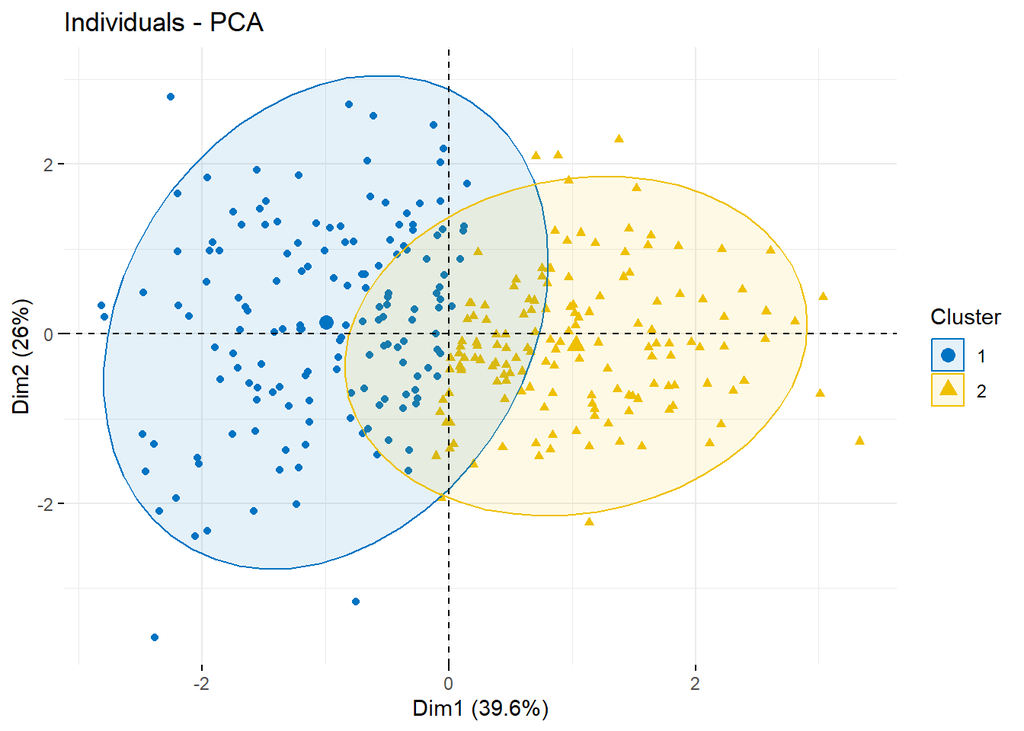

```r
# Visualize PCA with cluster assignment
fviz_pca_ind(prcomp(heart_disease_scaled),
             geom.ind = "point",
             col.ind = as.factor(kmeans_df$cluster),
             palette = "jco",
             addEllipses = TRUE,
             legend.title = "Cluster")
```

## Hierarchical clustering

This is an alternative to k-means clustering, with big advantage that it does not require pre-selection of the number of clusters to obtain in the end.

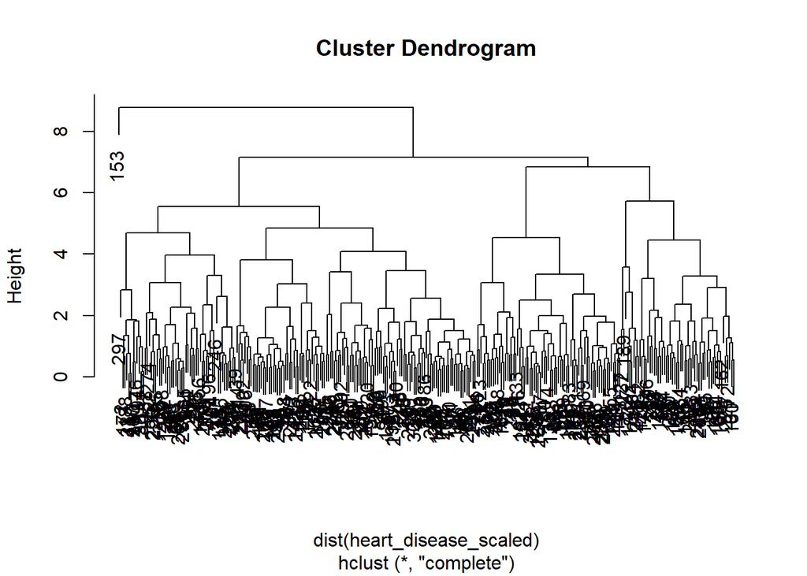

```r
# Calculate clusters based on default distance metrics - evaluate others!
hclust_result <- hclust(dist(heart_disease_scaled),
                        method = "complete")

# Create dendogram
plot(hclust_result)
```

# Part 2: Supervised learning

## Feature selection

When we have huge number of predictors we want to first reduce the number of features. With that we can: Improve model performance - irrelevant or redundant variables can confuse the model, causing overfitting. Reduce overfitting - models trained on too many features may fit noise instead of signal. Speed up training - important for complex models or large datasets. Improve model interpretability - fewer variables make it easier to understand and explain the model’s decisions. Avoid multicollinearity - helps remove such redundant variables.

### Feature selection with stepwise regression model

```r
# Full model
full_model <- glm(HeartDisease ~ .,
                  data = heart_disease,
                  family = binomial)

# Perform backward selection & select variables
step_model_back <- stepAIC(full_model,
                           direction = "backward",
                           trace = FALSE)
selected_vars_back <- names(coef(step_model_back))[-1]
selected_vars_back
```

```
[1] "SexMale"                   "ChestPainAtypical angina"
[3] "ChestPainNon-anginal pain" "ChestPainTypical angina"
[5] "BP"                        "Cholesterol"
[7] "MaximumHR"                 "ExerciseInducedAnginaYes"
```

```r
# Perform forward selection & select variables
step_model_for <- stepAIC(full_model,
                          direction = "forward",
                          trace = FALSE)
selected_vars_for <- names(coef(step_model_for))[-1]
selected_vars_for
```

```
 [1] "rownames"                  "Age"
 [3] "SexMale"                   "ChestPainAtypical angina"
 [5] "ChestPainNon-anginal pain" "ChestPainTypical angina"
 [7] "BP"                        "Cholesterol"
 [9] "BloodSugarTRUE"            "MaximumHR"
[11] "ExerciseInducedAnginaYes"
```

```r
# Perform both selection & select variables
step_model_both <- stepAIC(full_model,
                           direction = "both",
                           trace = FALSE)
selected_vars_both <- names(coef(step_model_both))[-1]
selected_vars_both
```

```
[1] "SexMale"                   "ChestPainAtypical angina"
[3] "ChestPainNon-anginal pain" "ChestPainTypical angina"
[5] "BP"                        "Cholesterol"
[7] "MaximumHR"                 "ExerciseInducedAnginaYes"
```

### Feature selection with Boruta random forest model

`Boruta` is a feature selection algorithm that adds shadow features (randomized copies of original features), trains a Random Forest model, compares importance of original vs shadow features, and iteratively confirms, rejects, or leaves undecided the features.

It gives a robust, data-driven way to filter out noise and works well with non-linear relationships.

Unlike stepwise methods, it respects feature interactions.

```r
# Run Boruta
model_boruta <- Boruta(HeartDisease ~ .,
                       data = heart_disease)
print(model_boruta)
```

```
Boruta performed 32 iterations in 2.354443 secs.
 6 attributes confirmed important: Age, BP, ChestPain,
ExerciseInducedAngina, MaximumHR and 1 more;
 3 attributes confirmed unimportant: BloodSugar, Cholesterol, rownames;
```

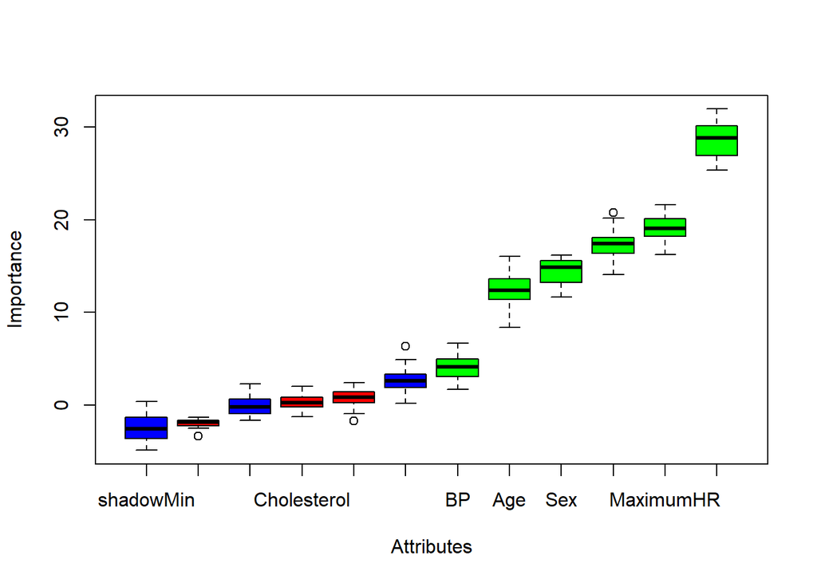

```r
plot(model_boruta)
```

```r
# Select confirmed features
selected_var <- getSelectedAttributes(model_boruta)

# Resolve tentative features (if any)
final_boruta <- TentativeRoughFix(model_boruta)
getSelectedAttributes(final_boruta)
```

```
[1] "Age"                   "Sex"                   "ChestPain"
[4] "BP"                    "MaximumHR"             "ExerciseInducedAngina"
```

## Splitting data into training and testing sets

Now we’ll use the caret library to split the dataset into training and testing sets. The `createDataPartition` function from the caret library helps us achieve this. We’ll partition 70% of the data for training and the remaining 30% for testing.

By splitting the data, you ensure that your model is trained and tested on different data, which helps in evaluating its real-world performance.

```r
heart_disease <- as.data.frame(heart_disease[, -1])

# Splitting data into training and testing sets
trainIndex <- createDataPartition(heart_disease$HeartDisease,
                                  p = 0.7,
                                  list = FALSE,
                                  times = 1)
trainData <- heart_disease[trainIndex, ]
testData <- heart_disease[-trainIndex, ]

# Print the number of rows in training and testing sets
print(nrow(trainData))
```

```
[1] 213
```

```r
table(trainData$HeartDisease)
```

```
 No Yes
115  98
```

```r
print(nrow(testData))
```

```
[1] 90
```

```r
table(testData$HeartDisease)
```

```
 No Yes
 49  41
```

## Feature scaling

Feature scaling is an important step to ensure that all data points are on a similar scale. This is especially important for algorithms that use distance measurements (e.g., K-Nearest Neighbors).

We’ll normalize (center and scale) the features using the `preProcess` function from the caret library. `preProcess` computes scaling parameters predict applies scaling to the data

```r
# Feature scaling (excluding factor columns)
numericColumns <- sapply(trainData, is.numeric)
preProcValues <- preProcess(trainData[, numericColumns[-1]], method = c("center", "scale"))
trainData[, numericColumns] <- predict(preProcValues,
                                       trainData[, numericColumns])
testData[, numericColumns] <- predict(preProcValues,
                                      testData[, numericColumns])
```

## Building and evaluating models

### Train a logistic regression model

```r
glm_model <- train(HeartDisease ~ .,
                   data = trainData,
                   method = "glm",
                   family = "binomial")
glm_model
```

```
Generalized Linear Model

213 samples
  8 predictor
  2 classes: 'No', 'Yes'

No pre-processing
Resampling: Bootstrapped (25 reps)
Summary of sample sizes: 213, 213, 213, 213, 213, 213, ...
Resampling results:

  Accuracy   Kappa
  0.7467924  0.4877528
```

```r
summary(glm_model)
```

```
Call:
NULL

Coefficients:
                             Estimate Std. Error z value Pr(>|z|)
(Intercept)                  2.236059   2.614243   0.855 0.392365
Age                          0.017221   0.025332   0.680 0.496629
SexMale                      1.907153   0.473389   4.029 5.61e-05 ***
`ChestPainAtypical angina`  -1.831258   0.551094  -3.323 0.000891 ***
`ChestPainNon-anginal pain` -1.867625   0.464303  -4.022 5.76e-05 ***
`ChestPainTypical angina`   -2.323870   0.715857  -3.246 0.001169 **
BP                           0.483273   0.200360   2.412 0.015864 *
Cholesterol                  0.005616   0.003792   1.481 0.138597
BloodSugarTRUE              -0.134908   0.482257  -0.280 0.779675
MaximumHR                   -0.035188   0.011113  -3.166 0.001543 **
ExerciseInducedAnginaYes     0.584593   0.435873   1.341 0.179855
---
Signif. codes:  0 '***' 0.001 '**' 0.01 '*' 0.05 '.' 0.1 ' ' 1

(Dispersion parameter for binomial family taken to be 1)

    Null deviance: 293.92  on 212  degrees of freedom
Residual deviance: 189.63  on 202  degrees of freedom
AIC: 211.63

Number of Fisher Scoring iterations: 5
```

### Make predictions and evaluate the model

```r
# Making predictions
predictions <- predict(glm_model, testData)

# Evaluating the model
confusion <- confusionMatrix(predictions, testData$HeartDisease)
print(confusion)
```

```
Confusion Matrix and Statistics

          Reference
Prediction No Yes
       No  44  10
       Yes  5  31

               Accuracy : 0.8333
                 95% CI : (0.74, 0.9036)
    No Information Rate : 0.5444
    P-Value [Acc > NIR] : 7.067e-09

                  Kappa : 0.6606

 Mcnemar's Test P-Value : 0.3017

            Sensitivity : 0.8980
            Specificity : 0.7561
         Pos Pred Value : 0.8148
         Neg Pred Value : 0.8611
             Prevalence : 0.5444
         Detection Rate : 0.4889
   Detection Prevalence : 0.6000
      Balanced Accuracy : 0.8270

       'Positive' Class : No
```

A confusion matrix is a table that is often used to describe the performance of a classification model on a set of test data for which the true values are known.

- True Positives (TP): The number of correct positive predictions.
- True Negatives (TN): The number of correct negative predictions.
- False Positives (FP): The number of incorrect positive predictions (also known as Type I errors).
- False Negatives (FN): The number of incorrect negative predictions (also known as Type II errors).

### Visual inspection of model and the importance of different features

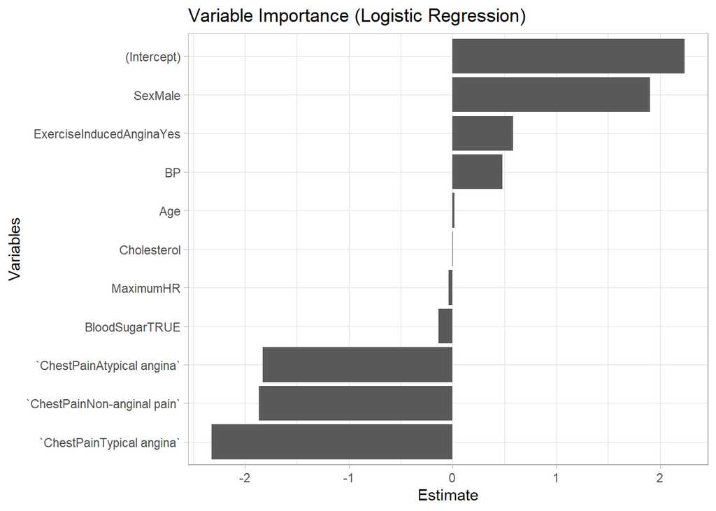

```r
# Visualizing the logistic regression coefficients
coef_df <- as.data.frame(coef(summary(glm_model$finalModel)))
coef_df$Variable <- rownames(coef_df)
names(coef_df)[1] <- "Estimate"

scatter_plot <- ggplot(coef_df, aes(x = reorder(Variable, Estimate), y = Estimate)) +
  geom_bar(stat = 'identity') +
  coord_flip() +
  theme_light() +
  labs(title = "Variable Importance (Logistic Regression)",
       x = "Variables",
       y = "Estimate")
scatter_plot
```

### Model generalization and validation through cross-validation

Cross-validation is a technique used to evaluate how well your model generalizes to unseen data by splitting the dataset into multiple subsets or “folds”. The model is trained on a portion of the data and validated on the remaining part, rotating through the folds to get a comprehensive performance metric. This helps ensure that your model isn’t just fitting noise in your training data but can perform well on independent datasets. It reduces the risk of overfitting and provides a more reliable estimate of model performance.

- Model Reliability - cross-validation helps you gauge the reliability of your model by testing it on different subsets of your data. This way, you reduce the risk of overfitting and ensure that your model has good performance across various datasets.
- Performance Metrics - it provides you with more robust performance metrics by averaging the results from different folds. This gives you a better understanding of your model’s capabilities.
- Real-World Readiness - in the real world, the data your model encounters can vary. Cross-validation ensures that your model is not just tailored to one specific dataset but is generalized for better real-world application.

```r
# Basic parameter tuning
fitControl <- trainControl(
  ## 10-fold CV
  method = "repeatedcv",
  number = 10,
  ## repeated ten times
  repeats = 10)
```

```r
# Create a model
glm_model_2 <- train(HeartDisease ~ .,
                     data = trainData,
                     method = "glm",
                     family = "binomial",
                     metric = "Accuracy",
                     trControl = fitControl)
glm_model_2
```

```
Generalized Linear Model

213 samples
  8 predictor
  2 classes: 'No', 'Yes'

No pre-processing
Resampling: Cross-Validated (10 fold, repeated 10 times)
Summary of sample sizes: 192, 192, 193, 192, 192, 191, ...
Resampling results:

  Accuracy   Kappa
  0.7701905  0.5336502
```

```r
summary(glm_model_2)
```

```
Call:
NULL

Coefficients:
                             Estimate Std. Error z value Pr(>|z|)
(Intercept)                  2.236059   2.614243   0.855 0.392365
Age                          0.017221   0.025332   0.680 0.496629
SexMale                      1.907153   0.473389   4.029 5.61e-05 ***
`ChestPainAtypical angina`  -1.831258   0.551094  -3.323 0.000891 ***
`ChestPainNon-anginal pain` -1.867625   0.464303  -4.022 5.76e-05 ***
`ChestPainTypical angina`   -2.323870   0.715857  -3.246 0.001169 **
BP                           0.483273   0.200360   2.412 0.015864 *
Cholesterol                  0.005616   0.003792   1.481 0.138597
BloodSugarTRUE              -0.134908   0.482257  -0.280 0.779675
MaximumHR                   -0.035188   0.011113  -3.166 0.001543 **
ExerciseInducedAnginaYes     0.584593   0.435873   1.341 0.179855
---
Signif. codes:  0 '***' 0.001 '**' 0.01 '*' 0.05 '.' 0.1 ' ' 1

(Dispersion parameter for binomial family taken to be 1)

    Null deviance: 293.92  on 212  degrees of freedom
Residual deviance: 189.63  on 202  degrees of freedom
AIC: 211.63

Number of Fisher Scoring iterations: 5
```

```r
# Making predictions
predictions_2 <- predict(glm_model_2, testData)

# Evaluating the model
confusion_2 <- confusionMatrix(predictions_2, testData$HeartDisease)
print(confusion_2)
```

```
Confusion Matrix and Statistics

          Reference
Prediction No Yes
       No  44  10
       Yes  5  31

               Accuracy : 0.8333
                 95% CI : (0.74, 0.9036)
    No Information Rate : 0.5444
    P-Value [Acc > NIR] : 7.067e-09

                  Kappa : 0.6606

 Mcnemar's Test P-Value : 0.3017

            Sensitivity : 0.8980
            Specificity : 0.7561
         Pos Pred Value : 0.8148
         Neg Pred Value : 0.8611
             Prevalence : 0.5444
         Detection Rate : 0.4889
   Detection Prevalence : 0.6000
      Balanced Accuracy : 0.8270

       'Positive' Class : No
```

##### TASK:

What if we choose only Boruta selected features?

```r
# Create a model
glm_model_Boruta <- train(HeartDisease ~ .,
                          data = trainData[, c("HeartDisease", selected_var)],
                          method = "glm",
                          family = "binomial",
                          metric = "Accuracy",
                          trControl = fitControl)
glm_model_Boruta
```

```
Generalized Linear Model

213 samples
  6 predictor
  2 classes: 'No', 'Yes'

No pre-processing
Resampling: Cross-Validated (10 fold, repeated 10 times)
Summary of sample sizes: 192, 191, 193, 192, 191, 191, ...
Resampling results:

  Accuracy   Kappa
  0.7698874  0.5345274
```

```r
summary(glm_model_Boruta)
```

```
Call:
NULL

Coefficients:
                            Estimate Std. Error z value Pr(>|z|)
(Intercept)                  3.02104    2.52150   1.198 0.230873
Age                          0.02190    0.02487   0.881 0.378533
SexMale                      1.71767    0.44505   3.859 0.000114 ***
`ChestPainAtypical angina`  -1.78515    0.54382  -3.283 0.001029 **
`ChestPainNon-anginal pain` -1.92352    0.45827  -4.197  2.7e-05 ***
`ChestPainTypical angina`   -2.32802    0.69986  -3.326 0.000880 ***
BP                           0.47159    0.19749   2.388 0.016944 *
MaximumHR                   -0.03228    0.01062  -3.040 0.002369 **
ExerciseInducedAnginaYes     0.63108    0.42565   1.483 0.138178
---
Signif. codes:  0 '***' 0.001 '**' 0.01 '*' 0.05 '.' 0.1 ' ' 1

(Dispersion parameter for binomial family taken to be 1)

    Null deviance: 293.92  on 212  degrees of freedom
Residual deviance: 191.88  on 204  degrees of freedom
AIC: 209.88

Number of Fisher Scoring iterations: 5
```

```r
# Making predictions
predictions_Boruta <- predict(glm_model_Boruta, testData)

# Evaluating the model
confusion_Boruta <- confusionMatrix(predictions_Boruta, testData$HeartDisease)
print(confusion_Boruta)
```

```
Confusion Matrix and Statistics

          Reference
Prediction No Yes
       No  44  11
       Yes  5  30

               Accuracy : 0.8222
                 95% CI : (0.7274, 0.8948)
    No Information Rate : 0.5444
    P-Value [Acc > NIR] : 2.84e-08

                  Kappa : 0.6373

 Mcnemar's Test P-Value : 0.2113

            Sensitivity : 0.8980
            Specificity : 0.7317
         Pos Pred Value : 0.8000
         Neg Pred Value : 0.8571
             Prevalence : 0.5444
         Detection Rate : 0.4889
   Detection Prevalence : 0.6111
      Balanced Accuracy : 0.8148

       'Positive' Class : No
```

##### TASK:

Try repeating the same steps for other methods, e.g. k-nearest neighbors (method = “knn”), support vector machine (method = “svmLinear”), random forest (method = “rf”), bagging (method = “treebag”).

Check all the possible models [here](https://topepo.github.io/caret/train-models-by-tag.html).

##### TASK:

Find out how to plot AUC (Area Under the Curve) for your test data. AUC represents the overall performance of a binary classification model based on the area under its ROC (Receiver Operating Characteristic) curve. A higher AUC value indicates better model performance, reflecting a greater ability to distinguish between classes. Essentially, it’s a single metric summarizing how well a model can differentiate between positive and negative instances.

*note: check pROC package